# 13704 AS Gadus morhua LI

### Assessment plots and statistical analysis

This report provides details of the assessment of arsenic concentrations in cod liver at station 20B Longyearbyen.

- Timeseries metadata. Key information about the timeseries.
- Assessment plot. The points are the annual medians of the individual log concentration measurements, with solid circles denoting uncensored values and < denoting less-than values. The points are plotted on the log scale, with the axis labels back-transformed for ease of interpretation. However, there are too few years, or too many less-than values, to fit a model to these data.
- Trend with data. The points are the individual concentration measurements, with + denoting uncensored values, d or q denoting values below the limit of detection or quantification and < denoting other less-than values.
- Auxiliary data. The individual concentration measurements with supporting information: mean length of the individuals in the sample; dry weight (%) of the sample; lipid weight (%) of the sample.
- Assessment (related compounds). Assessment plots for all the compounds in the same chemical group measured in cod liver at this station.
- Data (related compounds). A scatter plot matrix of all the individual concentration measurements for all the compounds in the same chemical group in cod liver at this station.
- Statistical analysis. No statistical analysis was done on these data.

#### Timeseries metadata

- OSPAR region: 1
- OSPAR subregion: Barents Sea
- Station code: 13704
- Station name: 20B Longyearbyen
- Station longname: 20B Longyearbyen, Svalbard
- Station latitude: 78.28
- Station longitude: 15.41
- Compartment: biota
- Species latin name: Gadus morhua
- Species common name: cod
- Tissue: liver
- Determinand code: AS
- Determinand name: arsenic
- Units: μg kg<sup>-1</sup> wet weight
- Extraction: 2024-09-27

#### Assessment plot

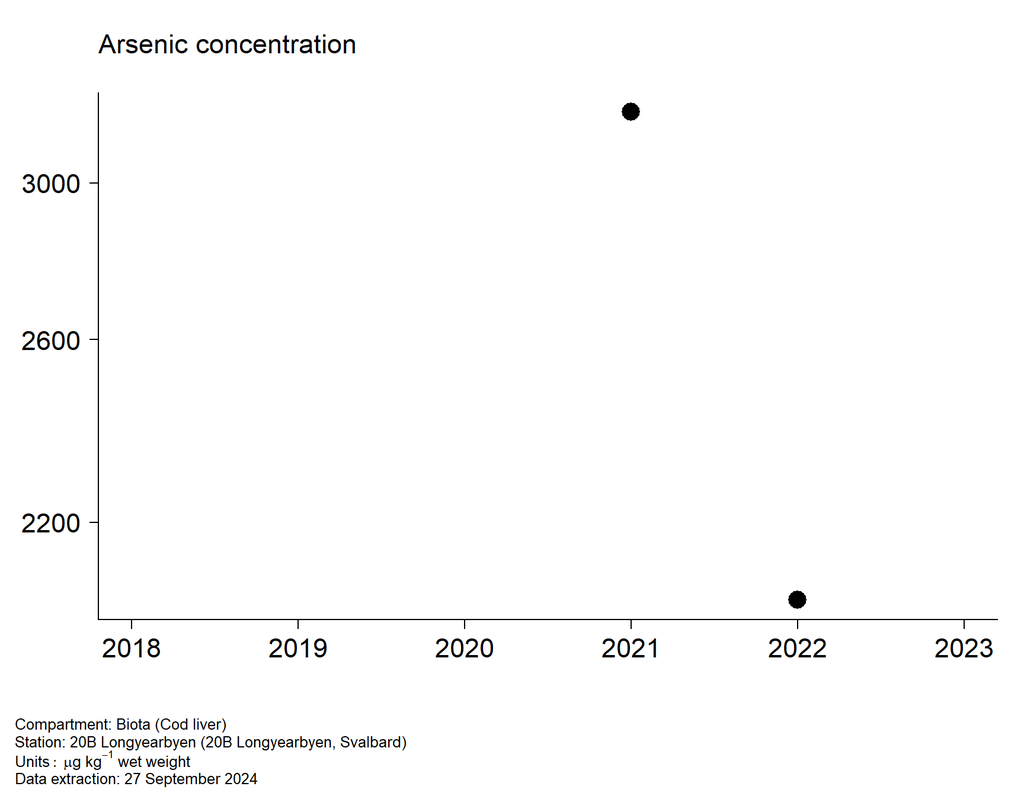

#### Trend with data

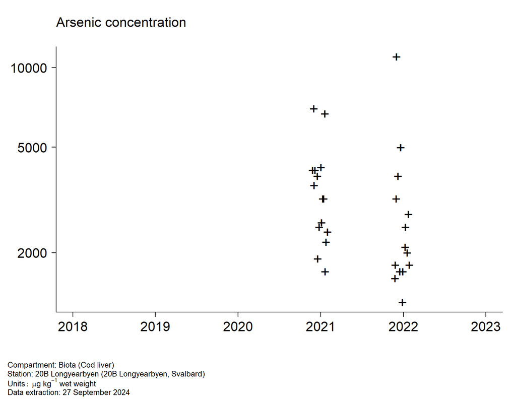

#### Auxiliary data

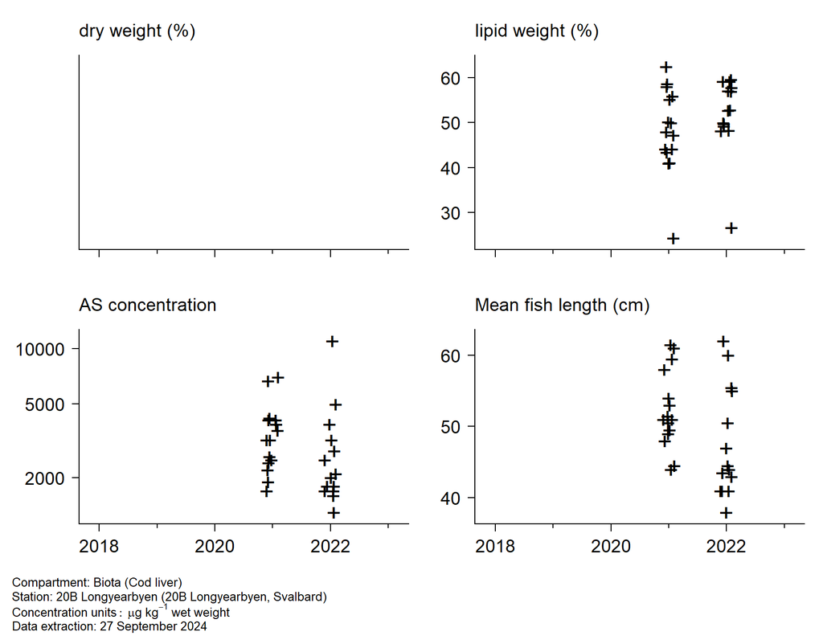

#### Assessments (related compounds)

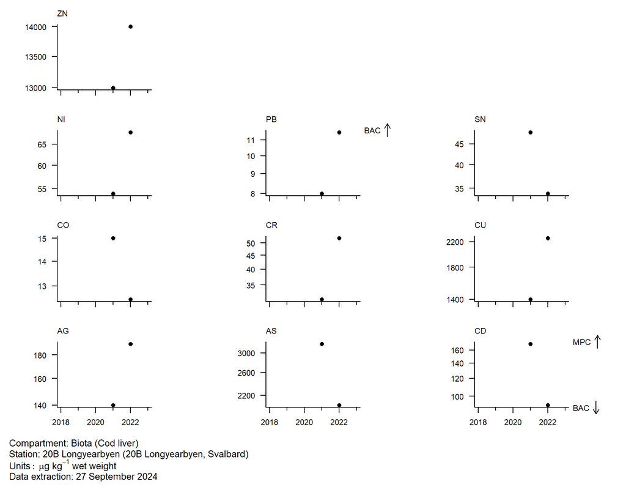

#### Data (related compounds)

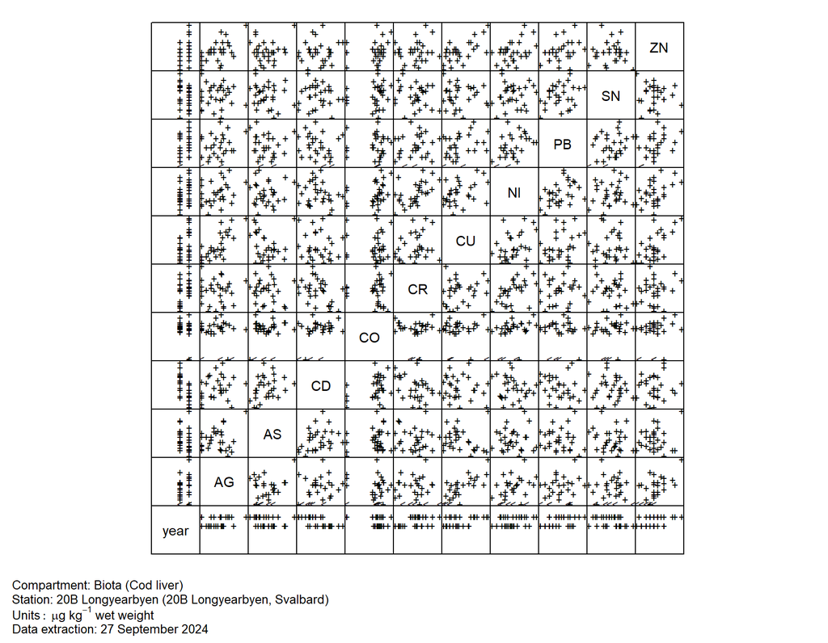

#### Statistical analysis

**Trend assessment**

There are too few years, or too many less-than values, for a trend assessment.

**Status assessment**

There are no assessment criteria so no status assessment is possible.